# Linear Modeling and Regression: Capabilities in R

REMEMBER: Comment why; not what  
And name functions & variables for their purpose

These images are brought to you by the stress reducing statistics site: [**statswithcats.wordpress.com**](https://statswithcats.wordpress.com/)

## Previously:

We covered **Correlation Coefficients (r)**.  
- also called the Pearson product moment correlation coefficient

Important properties:  
range from -0 to 1  
Positive value means that y increases with x  
Negative value means that y decreases with x

This helps us to look at our data and know if there is a trend buried within. Whatever it may be, our eyes are very good at noticing trends, but if we want a machine to pick it out then we have to look at R<sup>2</sup>.

We know that all datasets are not created equal. Many statistical attributes are effected by sample size, measurement variance, and outliers. These are things to be wary of especially in the assumptions we have prior to performing regression.  
Some key assumptions include:

1. The relationship between the dependent and independent variable is roughly linear
2. The variable are multivariate normal
3. There is little multicollinearity between the independent variables.

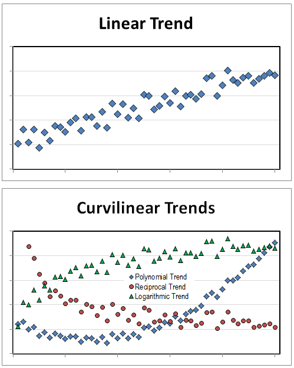

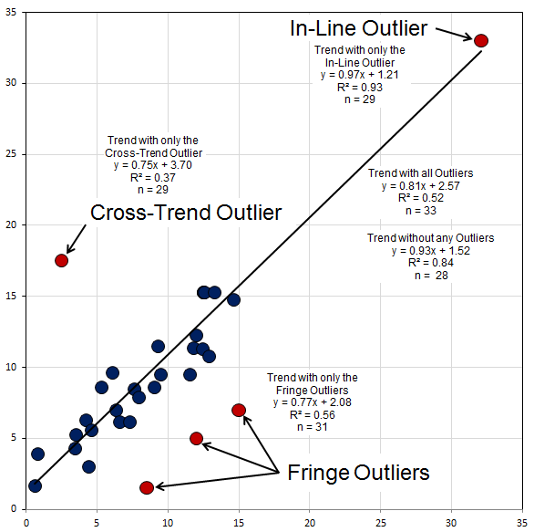

## Introduction to Data Modeling:

In a regression model we try to ascertain the variation in our dependent Y variable that is being caused by some independent X variable. Ideally, the model will capture true “signals” (i.e. patterns generated by the phenomenon of interest), and ignore “noise” (i.e. random variation that you’re not interested in). ( [r4ds](https://r4ds.had.co.nz/model-intro.html) )  
The uses for regression are numerous with the most common being predictive followed by hypothesis confirmation and exploratory. The goal of which is always; how well can we generalize from this specific information.

#### This section will cover an example with mtcars a built-in dataset contained in R.

The goal here is to gain some information on fuel efficiency from the information in the dataset. Let’s explore the dataset and see which variables may be useful in predicting the MPG column.

```r
mtcars
```

|  | mpg | cyl | disp | hp | drat | wt | qsec | vs | am | gear | carb |
| --- | --- | --- | --- | --- | --- | --- | --- | --- | --- | --- | --- |
| Mazda RX4 | 21.0 | 6 | 160.0 | 110 | 3.90 | 2.620 | 16.46 | 0 | 1 | 4 | 4 |
| Mazda RX4 Wag | 21.0 | 6 | 160.0 | 110 | 3.90 | 2.875 | 17.02 | 0 | 1 | 4 | 4 |
| Datsun 710 | 22.8 | 4 | 108.0 | 93 | 3.85 | 2.320 | 18.61 | 1 | 1 | 4 | 1 |
| Hornet 4 Drive | 21.4 | 6 | 258.0 | 110 | 3.08 | 3.215 | 19.44 | 1 | 0 | 3 | 1 |
| Hornet Sportabout | 18.7 | 8 | 360.0 | 175 | 3.15 | 3.440 | 17.02 | 0 | 0 | 3 | 2 |
| Valiant | 18.1 | 6 | 225.0 | 105 | 2.76 | 3.460 | 20.22 | 1 | 0 | 3 | 1 |
| Duster 360 | 14.3 | 8 | 360.0 | 245 | 3.21 | 3.570 | 15.84 | 0 | 0 | 3 | 4 |
| Merc 240D | 24.4 | 4 | 146.7 | 62 | 3.69 | 3.190 | 20.00 | 1 | 0 | 4 | 2 |
| Merc 230 | 22.8 | 4 | 140.8 | 95 | 3.92 | 3.150 | 22.90 | 1 | 0 | 4 | 2 |
| Merc 280 | 19.2 | 6 | 167.6 | 123 | 3.92 | 3.440 | 18.30 | 1 | 0 | 4 | 4 |

[output cut: 22 more lines]

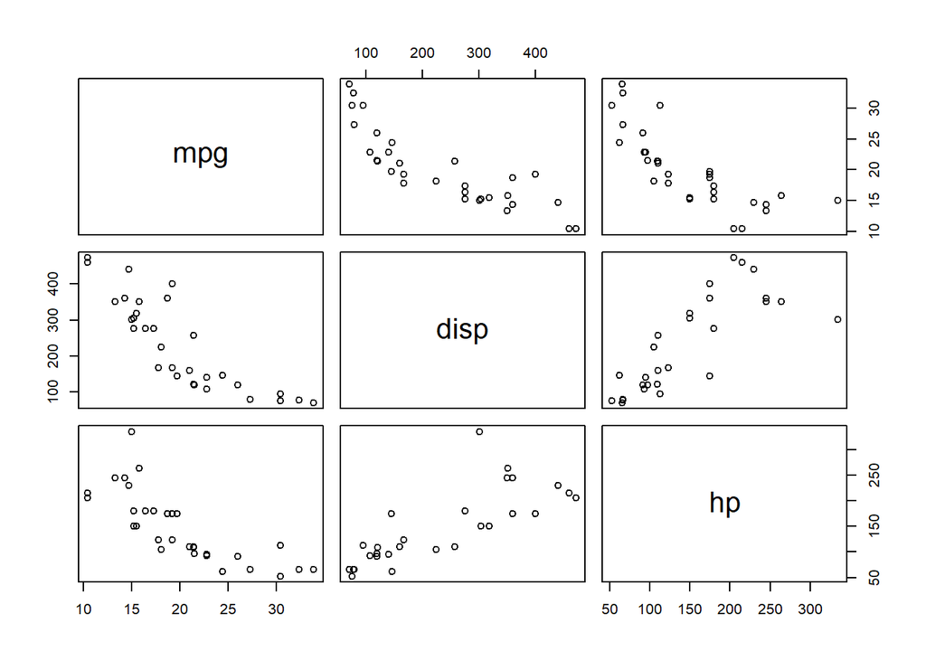

```r
pairs(mtcars[,c(1,3:4)])
```

## Before we get too far:

How do we build and interpret models?

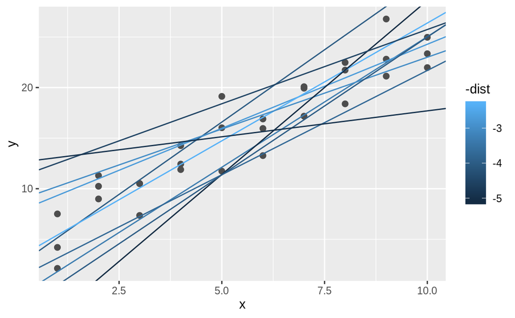

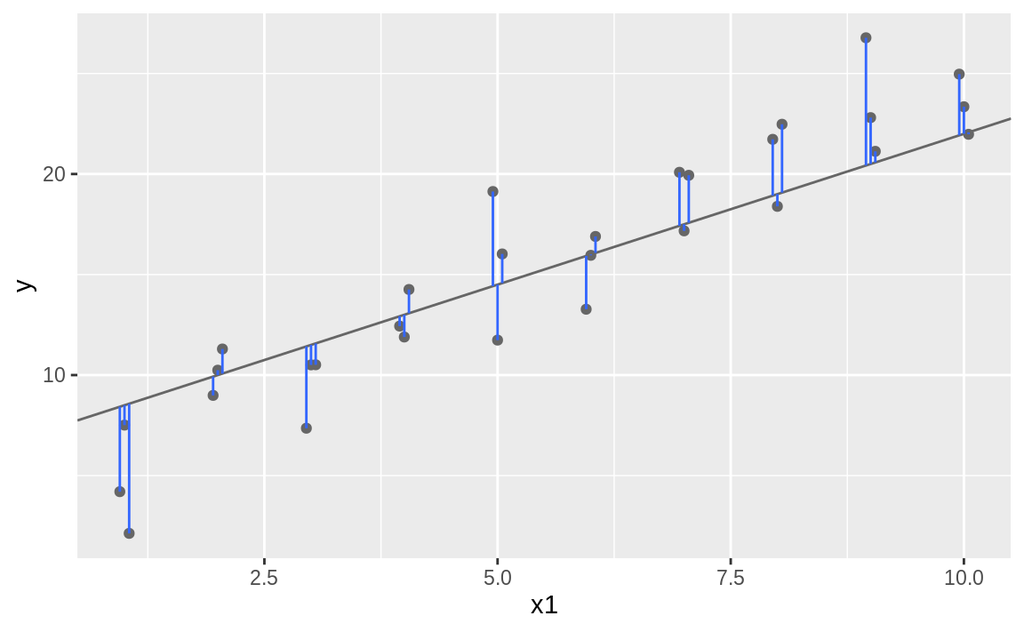

```r
summary(lm(mpg ~ ., mtcars))
```

```
##
## Call:
## lm(formula = mpg ~ ., data = mtcars)
##
## Residuals:
##     Min      1Q  Median      3Q     Max
## -3.4506 -1.6044 -0.1196  1.2193  4.6271
##
## Coefficients:
##             Estimate Std. Error t value Pr(>|t|)
## (Intercept) 12.30337   18.71788   0.657   0.5181
## cyl         -0.11144    1.04502  -0.107   0.9161
## disp         0.01334    0.01786   0.747   0.4635
## hp          -0.02148    0.02177  -0.987   0.3350
## drat         0.78711    1.63537   0.481   0.6353
## wt          -3.71530    1.89441  -1.961   0.0633 .
## qsec         0.82104    0.73084   1.123   0.2739
## vs           0.31776    2.10451   0.151   0.8814
## am           2.52023    2.05665   1.225   0.2340
## gear         0.65541    1.49326   0.439   0.6652
## carb        -0.19942    0.82875  -0.241   0.8122
## ---
## Signif. codes:  0 '***' 0.001 '**' 0.01 '*' 0.05 '.' 0.1 ' ' 1
##
## Residual standard error: 2.65 on 21 degrees of freedom
## Multiple R-squared:  0.869,  Adjusted R-squared:  0.8066
## F-statistic: 13.93 on 10 and 21 DF,  p-value: 3.793e-07
```

```r
summary(lm(mpg ~ wt, mtcars))
```

```
##
## Call:
## lm(formula = mpg ~ wt, data = mtcars)
##
## Residuals:
##     Min      1Q  Median      3Q     Max
## -4.5432 -2.3647 -0.1252  1.4096  6.8727
##
## Coefficients:
##             Estimate Std. Error t value Pr(>|t|)
## (Intercept)  37.2851     1.8776  19.858  < 2e-16 ***
## wt           -5.3445     0.5591  -9.559 1.29e-10 ***
## ---
## Signif. codes:  0 '***' 0.001 '**' 0.01 '*' 0.05 '.' 0.1 ' ' 1
##
## Residual standard error: 3.046 on 30 degrees of freedom
## Multiple R-squared:  0.7528, Adjusted R-squared:  0.7446
## F-statistic: 91.38 on 1 and 30 DF,  p-value: 1.294e-10
```

**Call:** This is an R feature that shows what function and parameters were used to create the model.  
**Residuals:** Difference between what the model predicted and the actual value of y.  
**Coefficients:** These are the weights that minimize the sum of the square of the errors.

**Residual Standard Error:** Essentially standard deviation of residuals / errors of your regression model.  
**Multiple R-Squared:** Percent of the variance of Y intact after subtracting the error of the model.  
**Adjusted R-Squared:** Same as multiple R-Squared but takes into account the number of samples and variables you’re using.  
**F-Statistic:** Global test to check if your model has at least one significant variable. Takes into account number of variables and observations used.

[Detailed Explanation of Summary()](http://www.learnbymarketing.com/tutorials/linear-regression-in-r/)

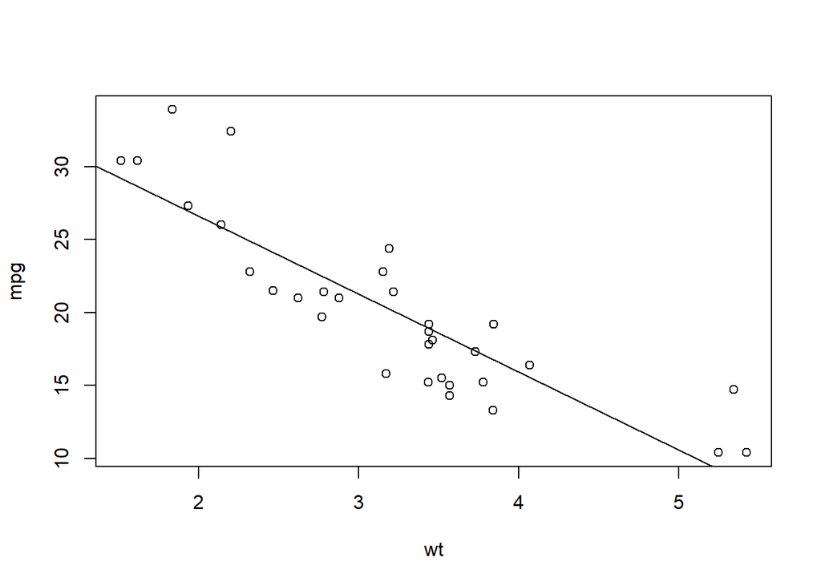

```
## integer(0)
```

```r
# We could possible compare the two or plot the resituals or other values from the fitted model
# fit1 <- lm(mpg ~ . , mtcars)
# fit2 <- lm(mpg ~ wt, mtcars)
#
# anova(fit1, fit2)   # Compare models
#
# plot(fit2)          # Plot the parameters of the fitted model

plot(mpg ~ wt, data = mtcars) +
  abline( lm(mpg~wt, data = mtcars))
```

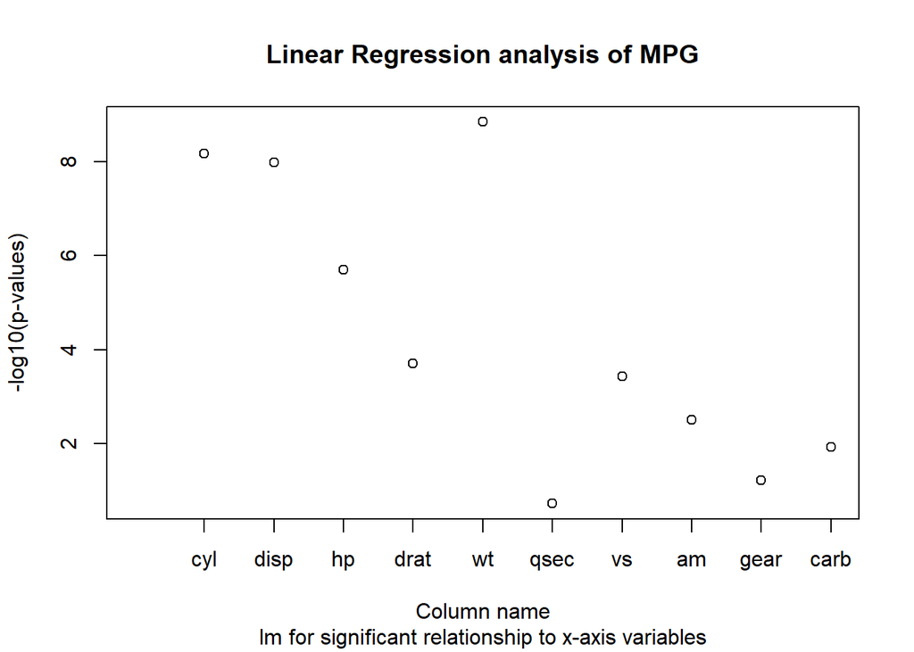

```r
p_values <- rep(0,dim(mtcars)[2]-1)
for( i in 2:dim(mtcars)[2] ){  # 11 columns - 1 mpg column
  variable <- mtcars[,i]  # extract column
  fit <- lm( mpg ~ variable, data = mtcars)  # linear-fit
  p_values[i] <- summary(fit)$coefficients[2,4]  # now all p-values of the GLM fit can be found
}

# This correction is not strictly neccessary but would help in instances of multiple comparisons (same item tests)
adj_p_values = p.adjust(p_values, "bonferroni")
names(adj_p_values) <- names(mtcars)[2:11]

# -log10(p-values): A Manhattan Plot
plot(-log10(adj_p_values), main = "Linear Regression analysis of MPG", xlab = "Column name", ylab = "-log10(p-values)", sub = "lm for significant relationship to x-axis variables", xaxt = "n")
axis(1,at=2:12,labels=names(adj_p_values))
```

ENDING THE FIRST

### Multiple Variable Regression:

AIC is a number that is helpful for comparing models as it includes measures of both how well the model fits the data and how complex the model is.

```r
min.model <- ( lm(mpg~1, data = mtcars) )
biggest <- formula( lm(mpg~., mtcars) )
# > biggest
# > mpg ~ cyl + disp + hp + drat + wt + qsec + vs + am + gear + carb

fwd.model = step(min.model, direction='forward', scope=biggest)
```

```
## Start:  AIC=115.94
## mpg ~ 1
##
##        Df Sum of Sq     RSS     AIC
## + wt    1    847.73  278.32  73.217
## + cyl   1    817.71  308.33  76.494
## + disp  1    808.89  317.16  77.397
## + hp    1    678.37  447.67  88.427
## + drat  1    522.48  603.57  97.988
## + vs    1    496.53  629.52  99.335
## + am    1    405.15  720.90 103.672
## + carb  1    341.78  784.27 106.369
## + gear  1    259.75  866.30 109.552
## + qsec  1    197.39  928.66 111.776
## <none>              1126.05 115.943
##
## Step:  AIC=73.22
## mpg ~ wt
##
##        Df Sum of Sq    RSS    AIC
## + cyl   1    87.150 191.17 63.198
## + hp    1    83.274 195.05 63.840
## + qsec  1    82.858 195.46 63.908
## + vs    1    54.228 224.09 68.283
## + carb  1    44.602 233.72 69.628
## + disp  1    31.639 246.68 71.356
## <none>              278.32 73.217
## + drat  1     9.081 269.24 74.156
## + gear  1     1.137 277.19 75.086
## + am    1     0.002 278.32 75.217
##
## Step:  AIC=63.2
## mpg ~ wt + cyl
##
##        Df Sum of Sq    RSS    AIC
## + hp    1   14.5514 176.62 62.665
## + carb  1   13.7724 177.40 62.805
## <none>              191.17 63.198
## + qsec  1   10.5674 180.60 63.378
## + gear  1    3.0281 188.14 64.687
## + disp  1    2.6796 188.49 64.746
## + vs    1    0.7059 190.47 65.080
## + am    1    0.1249 191.05 65.177
## + drat  1    0.0010 191.17 65.198
##
## Step:  AIC=62.66
## mpg ~ wt + cyl + hp
##
##        Df Sum of Sq    RSS    AIC
## <none>              176.62 62.665
## + am    1    6.6228 170.00 63.442
## + disp  1    6.1762 170.44 63.526
## + carb  1    2.5187 174.10 64.205
## + drat  1    2.2453 174.38 64.255
## + qsec  1    1.4010 175.22 64.410
## + gear  1    0.8558 175.76 64.509
## + vs    1    0.0599 176.56 64.654
```

```r
##### Multivariate linear fit and prediction
fit <- lm(mpg ~ wt + cyl + hp, data = mtcars)
summary(fit)
```

```
##
## Call:
## lm(formula = mpg ~ wt + cyl + hp, data = mtcars)
##
## Residuals:
##     Min      1Q  Median      3Q     Max
## -3.9290 -1.5598 -0.5311  1.1850  5.8986
##
## Coefficients:
##             Estimate Std. Error t value Pr(>|t|)
## (Intercept) 38.75179    1.78686  21.687  < 2e-16 ***
## wt          -3.16697    0.74058  -4.276 0.000199 ***
## cyl         -0.94162    0.55092  -1.709 0.098480 .
## hp          -0.01804    0.01188  -1.519 0.140015
## ---
## Signif. codes:  0 '***' 0.001 '**' 0.01 '*' 0.05 '.' 0.1 ' ' 1
##
## Residual standard error: 2.512 on 28 degrees of freedom
## Multiple R-squared:  0.8431, Adjusted R-squared:  0.8263
## F-statistic: 50.17 on 3 and 28 DF,  p-value: 2.184e-11
```

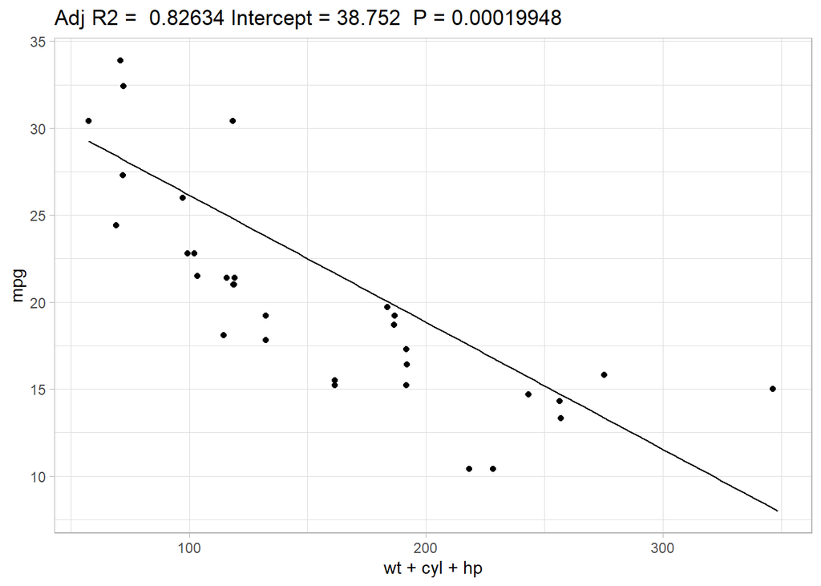

```r
# This will smooth the line
p_wt <- seq(min(wt), max(wt), length.out=100)
p_cyl <- seq(min(cyl), max(cyl), length.out=100)
p_hp <- seq(min(hp), max(hp), length.out=100)
p_data = data.frame( wt = p_wt, cyl = p_cyl, hp = p_hp )
p <- predict(fit, newdata = p_data)

##### Plot
ggplot(mtcars, aes(x = wt + cyl + hp, y = mpg)) +
  geom_point() +
  geom_line(data = as.data.frame(p_data), aes(p_wt + p_cyl + p_hp, p)) +
  # geom_smooth(method = "loess") +
  theme_light() +
  labs(title = paste("Adj R2 = ",signif(summary(fit)$adj.r.squared, 5),
                     "Intercept =",signif(fit$coef[[1]],5 ),
                     # " Slope =",signif(fit$coef[[2]], 5),
                     " P =",signif(summary(fit)$coef[2,4], 5)))
```

___

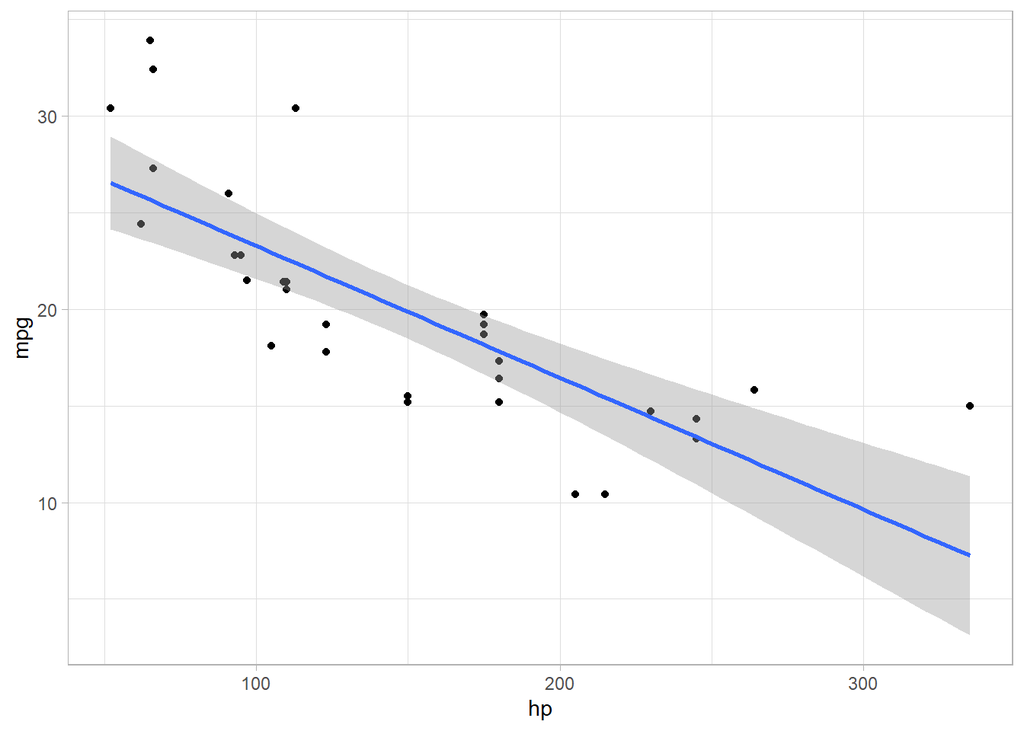

```r
library(ggplot2)
attach(mtcars)
ggplot(mtcars, aes(x = hp, y = mpg)) +
  geom_point() +
  # geom_line() +
  geom_smooth(method = "lm") +
  theme_light()
```

```r
##### Linear fit and prediction
fit <- lm( mpg ~ hp )
summary(fit)
```

```
##
## Call:
## lm(formula = mpg ~ hp)
##
## Residuals:
##     Min      1Q  Median      3Q     Max
## -5.7121 -2.1122 -0.8854  1.5819  8.2360
##
## Coefficients:
##             Estimate Std. Error t value Pr(>|t|)
## (Intercept) 30.09886    1.63392  18.421  < 2e-16 ***
## hp          -0.06823    0.01012  -6.742 1.79e-07 ***
## ---
## Signif. codes:  0 '***' 0.001 '**' 0.01 '*' 0.05 '.' 0.1 ' ' 1
##
## Residual standard error: 3.863 on 30 degrees of freedom
## Multiple R-squared:  0.6024, Adjusted R-squared:  0.5892
## F-statistic: 45.46 on 1 and 30 DF,  p-value: 1.788e-07
```

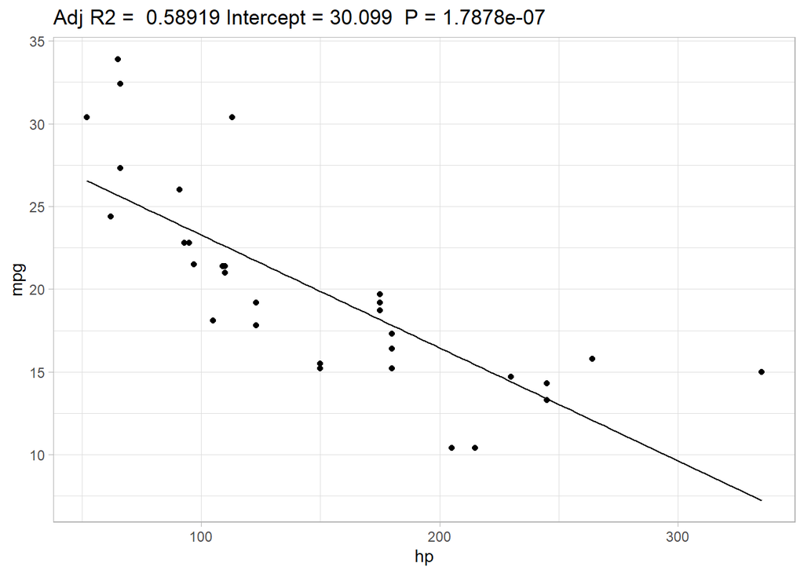

```r
p_hp <- seq(min(hp), max(hp), length.out=100)
p_data = data.frame( hp = p_hp )
p <- predict(fit, newdata = data.frame( hp = p_hp ))

##### Plot
ggplot(mtcars, aes(x = hp, y = mpg)) +
  geom_point() +
  geom_line(data = as.data.frame(p_data), aes(p_hp, p)) +
  # geom_smooth(method = "lm") +
  theme_light() +
  labs(title = paste("Adj R2 = ",signif(summary(fit)$adj.r.squared, 5),
                     "Intercept =",signif(fit$coef[[1]],5 ),
                     # " Slope =",signif(fit$coef[[2]], 5),
                     " P =",signif(summary(fit)$coef[2,4], 5)))
```

```r
##### polynomial fit and prediction
fit <- lm(mpg ~ hp + I(hp^2))
summary(fit)
```

```
##
## Call:
## lm(formula = mpg ~ hp + I(hp^2))
##
## Residuals:
##     Min      1Q  Median      3Q     Max
## -4.5512 -1.6027 -0.6977  1.5509  8.7213
##
## Coefficients:
##               Estimate Std. Error t value Pr(>|t|)
## (Intercept)  4.041e+01  2.741e+00  14.744 5.23e-15 ***
## hp          -2.133e-01  3.488e-02  -6.115 1.16e-06 ***
## I(hp^2)      4.208e-04  9.844e-05   4.275 0.000189 ***
## ---
## Signif. codes:  0 '***' 0.001 '**' 0.01 '*' 0.05 '.' 0.1 ' ' 1
##
## Residual standard error: 3.077 on 29 degrees of freedom
## Multiple R-squared:  0.7561, Adjusted R-squared:  0.7393
## F-statistic: 44.95 on 2 and 29 DF,  p-value: 1.301e-09
```

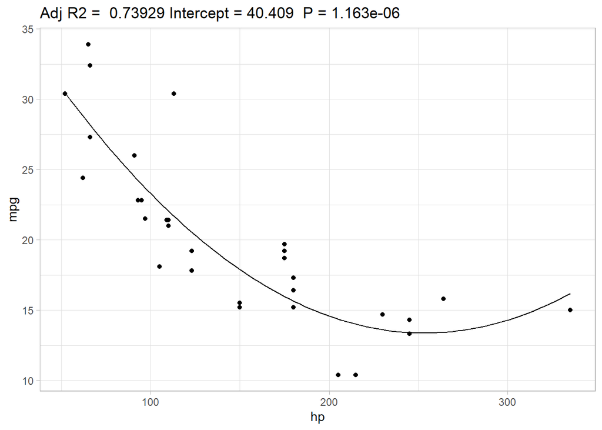

```r
p_hp <- seq(min(hp), max(hp), length.out=100)
p_data = data.frame( hp = p_hp )
p <- predict(fit, newdata = data.frame( hp = p_hp ))

##### Plot
ggplot(mtcars, aes(x = hp, y = mpg)) +
  geom_point() +
  geom_line(data = as.data.frame(p_data), aes(p_hp, p)) +
  # geom_smooth(method = "loess") +
  theme_light() +
  labs(title = paste("Adj R2 = ",signif(summary(fit)$adj.r.squared, 5),
                     "Intercept =",signif(fit$coef[[1]],5 ),
                     # " Slope =",signif(fit$coef[[2]], 5),
                     " P =",signif(summary(fit)$coef[2,4], 5)))
```

### Multivariate polynomial fit and prediction

Combine the previous two explorations

```r
##### Multivariate polynomial fit and prediction
fit <- lm(mpg ~ wt + I(wt^2) + hp + I(hp^2))
summary(fit)
```

```
##
## Call:
## lm(formula = mpg ~ wt + I(wt^2) + hp + I(hp^2))
##
## Residuals:
##     Min      1Q  Median      3Q     Max
## -2.8849 -1.8165 -0.3922  1.3499  4.5807
##
## Coefficients:
##               Estimate Std. Error t value Pr(>|t|)
## (Intercept)  4.945e+01  3.521e+00  14.044 6.27e-14 ***
## wt          -9.220e+00  2.270e+00  -4.062 0.000375 ***
## I(wt^2)      8.500e-01  3.005e-01   2.829 0.008700 **
## hp          -9.428e-02  3.193e-02  -2.952 0.006456 **
## I(hp^2)      1.743e-04  8.073e-05   2.159 0.039879 *
## ---
## Signif. codes:  0 '***' 0.001 '**' 0.01 '*' 0.05 '.' 0.1 ' ' 1
##
## Residual standard error: 2.135 on 27 degrees of freedom
## Multiple R-squared:  0.8907, Adjusted R-squared:  0.8745
## F-statistic: 55.02 on 4 and 27 DF,  p-value: 1.363e-12
```

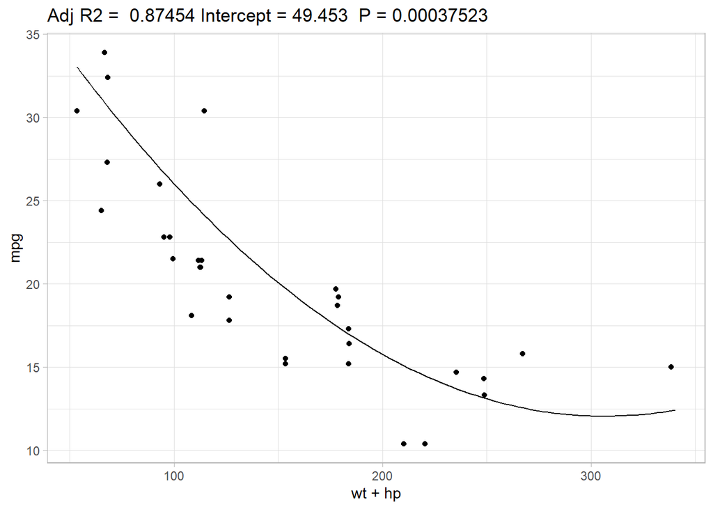

```r
# This will smooth the line
p_wt <- seq(min(wt), max(wt), length.out=100)
p_wt2 <- seq(min(wt), max(wt^2), length.out=100)
# p_cyl <- seq(min(cyl), max(cyl), length.out=100)
p_hp <- seq(min(hp), max(hp), length.out=100)
p_hp2 <- seq(min(hp), max(hp^2), length.out=100)
p_data = data.frame( wt = p_wt, `I(wt^2)` = p_wt2,
                                        hp = p_hp, `I(hp^2)` = p_hp2 )
p <- predict(fit, newdata = p_data)

##### Plot
ggplot(mtcars, aes(x = wt + hp, y = mpg)) +
  geom_point() +
  geom_line(data = as.data.frame(p_data), aes(p_wt + p_hp, p)) +
  # geom_smooth(method = "loess") +
  theme_light() +
  labs(title = paste("Adj R2 = ",signif(summary(fit)$adj.r.squared, 5),
                     "Intercept =",signif(fit$coef[[1]],5 ),
                     # " Slope =",signif(fit$coef[[2]], 5),
                     " P =",signif(summary(fit)$coef[2,4], 5)))
```

1. Correlation coefficint (r) also called the Pearson product moment correlation coefficient

Important properites: range from -0 to 1 Positive value means that y increases with x Negative value means that y decreases with x

example from Applied Statistics section of Statistics Quick Refernce android app

2. Linear Regression:

if correlation coefficient is large (close to -1 or 1) then the next step would be to fit a regression line; which is to find a line that best fits or models the data. One purpose for the model is to make predictions. Here we will discuss Least squares linear regression.

Simple Linear regression is appropriate when there is a linear relationship - this can be checkeed by making an XY scatterplot and visually checking if this is linear.

The method for constructing such a line.

Explanation of Linear Regression

How to do linear regression in R with the cars dataset

Break down what linear modeling actually produces

Break down the summary of lm - Maybe AIC for comparing models - with covariates

show plotting options - with plot(x,y) + abline(lm(y~x)) - also plot(x,y) + abline(lm(y~x^2)) + or geom_smooth()

Ultimately reach a point where they can get a linear model or a graphical line out of anything

THEN~~~ Ruin their idea with multicolinearity and the 3d plot - IDK how to do this

There are several reasons to perform regression, and a number of ways to view the results.

We may want to predict an event or effect using simple easy to aquire mesurements (extrapolate). We may want to check if there is an effect from our dependent variable (interpolate).

Identify which variable is causing an effect (affecting the trend) [variable selection]

```r
# library("mnormt")
# n = 300; pe1 = 0.5; pe2 = 0.5; set.seed(99);
# s1 <- matrix(c(4,2,2,4),2,2)  # the origin of the distribution
# s2 <- matrix(c(1,0,0,1),2,2)  # some significantly different distribution
# m1 <- c(2,0)                  # centre
# m2 <- c(0,0)                # centre
#
# effect_a <- rmnorm(n*pe1, m1, s1)  # Simulation under effect a
# effect_b <- rmnorm(n*pe1, m2, s2)  # Simulation under effect b
#
# big_data <- rbind(a,b)
# #_
# bigger_data <- as.data.frame(cbind(big_data, as.factor(c(rep(1,n*pe1),rep(2,n*pe2)))))
# plot(bigger_data, col = bigger_data[,3])
# ggplot(bigger_data, aes(bigger_data[,1], bigger_data[,2], col = as.factor(bigger_data[,3]))) +
#   geom_point() +
#   geom_smooth()
#
```

Principles of good coding:

1. Name variable based on what they are used for
2. Comment why you are doing something

example( )

```r
# car_data <- cbind( model = rownames(mtcars), mtcars)
# test_cars_lm0 <-  glm(cyl~., data = mtcars)
# car::ceresPlot(test_cars_lm0, variable = "wt")
# car::ceresPlot(test_cars_lm0, variable = "hp")
# car::ceresPlot(test_cars_lm0, variable = "disp")
# car::ceresPlots(test_cars_lm0)
# car::ceresPlot(test_cars_lm0, variable = "gear")
```

2 things that make models harder to interpret" - having few samples - having many variables

This is the trend we are heading towards and the subject I would like to address here today. “So stop recording a lot of variables, thanks”. Problem solved right? But what do we do with the data already recorded.

Forward step regression

```r
# using mtcars find the combination of factors that best predicts mpg
mtcars
```

|  | mpg | cyl | disp | hp | drat | wt | qsec | vs | am | gear | carb |
| --- | --- | --- | --- | --- | --- | --- | --- | --- | --- | --- | --- |
| Mazda RX4 | 21.0 | 6 | 160.0 | 110 | 3.90 | 2.620 | 16.46 | 0 | 1 | 4 | 4 |
| Mazda RX4 Wag | 21.0 | 6 | 160.0 | 110 | 3.90 | 2.875 | 17.02 | 0 | 1 | 4 | 4 |
| Datsun 710 | 22.8 | 4 | 108.0 | 93 | 3.85 | 2.320 | 18.61 | 1 | 1 | 4 | 1 |
| Hornet 4 Drive | 21.4 | 6 | 258.0 | 110 | 3.08 | 3.215 | 19.44 | 1 | 0 | 3 | 1 |
| Hornet Sportabout | 18.7 | 8 | 360.0 | 175 | 3.15 | 3.440 | 17.02 | 0 | 0 | 3 | 2 |
| Valiant | 18.1 | 6 | 225.0 | 105 | 2.76 | 3.460 | 20.22 | 1 | 0 | 3 | 1 |
| Duster 360 | 14.3 | 8 | 360.0 | 245 | 3.21 | 3.570 | 15.84 | 0 | 0 | 3 | 4 |
| Merc 240D | 24.4 | 4 | 146.7 | 62 | 3.69 | 3.190 | 20.00 | 1 | 0 | 4 | 2 |
| Merc 230 | 22.8 | 4 | 140.8 | 95 | 3.92 | 3.150 | 22.90 | 1 | 0 | 4 | 2 |
| Merc 280 | 19.2 | 6 | 167.6 | 123 | 3.92 | 3.440 | 18.30 | 1 | 0 | 4 | 4 |

[output cut: 22 more lines]

```r
knitr::kable(mtcars)
```

|  | mpg | cyl | disp | hp | drat | wt | qsec | vs | am | gear | carb |
| --- | --- | --- | --- | --- | --- | --- | --- | --- | --- | --- | --- |
| Mazda RX4 | 21.0 | 6 | 160.0 | 110 | 3.90 | 2.620 | 16.46 | 0 | 1 | 4 | 4 |
| Mazda RX4 Wag | 21.0 | 6 | 160.0 | 110 | 3.90 | 2.875 | 17.02 | 0 | 1 | 4 | 4 |
| Datsun 710 | 22.8 | 4 | 108.0 | 93 | 3.85 | 2.320 | 18.61 | 1 | 1 | 4 | 1 |
| Hornet 4 Drive | 21.4 | 6 | 258.0 | 110 | 3.08 | 3.215 | 19.44 | 1 | 0 | 3 | 1 |
| Hornet Sportabout | 18.7 | 8 | 360.0 | 175 | 3.15 | 3.440 | 17.02 | 0 | 0 | 3 | 2 |
| Valiant | 18.1 | 6 | 225.0 | 105 | 2.76 | 3.460 | 20.22 | 1 | 0 | 3 | 1 |
| Duster 360 | 14.3 | 8 | 360.0 | 245 | 3.21 | 3.570 | 15.84 | 0 | 0 | 3 | 4 |
| Merc 240D | 24.4 | 4 | 146.7 | 62 | 3.69 | 3.190 | 20.00 | 1 | 0 | 4 | 2 |
| Merc 230 | 22.8 | 4 | 140.8 | 95 | 3.92 | 3.150 | 22.90 | 1 | 0 | 4 | 2 |
| Merc 280 | 19.2 | 6 | 167.6 | 123 | 3.92 | 3.440 | 18.30 | 1 | 0 | 4 | 4 |
| Merc 280C | 17.8 | 6 | 167.6 | 123 | 3.92 | 3.440 | 18.90 | 1 | 0 | 4 | 4 |
| Merc 450SE | 16.4 | 8 | 275.8 | 180 | 3.07 | 4.070 | 17.40 | 0 | 0 | 3 | 3 |
| Merc 450SL | 17.3 | 8 | 275.8 | 180 | 3.07 | 3.730 | 17.60 | 0 | 0 | 3 | 3 |
| Merc 450SLC | 15.2 | 8 | 275.8 | 180 | 3.07 | 3.780 | 18.00 | 0 | 0 | 3 | 3 |
| Cadillac Fleetwood | 10.4 | 8 | 472.0 | 205 | 2.93 | 5.250 | 17.98 | 0 | 0 | 3 | 4 |
| Lincoln Continental | 10.4 | 8 | 460.0 | 215 | 3.00 | 5.424 | 17.82 | 0 | 0 | 3 | 4 |
| Chrysler Imperial | 14.7 | 8 | 440.0 | 230 | 3.23 | 5.345 | 17.42 | 0 | 0 | 3 | 4 |
| Fiat 128 | 32.4 | 4 | 78.7 | 66 | 4.08 | 2.200 | 19.47 | 1 | 1 | 4 | 1 |
| Honda Civic | 30.4 | 4 | 75.7 | 52 | 4.93 | 1.615 | 18.52 | 1 | 1 | 4 | 2 |
| Toyota Corolla | 33.9 | 4 | 71.1 | 65 | 4.22 | 1.835 | 19.90 | 1 | 1 | 4 | 1 |
| Toyota Corona | 21.5 | 4 | 120.1 | 97 | 3.70 | 2.465 | 20.01 | 1 | 0 | 3 | 1 |
| Dodge Challenger | 15.5 | 8 | 318.0 | 150 | 2.76 | 3.520 | 16.87 | 0 | 0 | 3 | 2 |
| AMC Javelin | 15.2 | 8 | 304.0 | 150 | 3.15 | 3.435 | 17.30 | 0 | 0 | 3 | 2 |
| Camaro Z28 | 13.3 | 8 | 350.0 | 245 | 3.73 | 3.840 | 15.41 | 0 | 0 | 3 | 4 |
| Pontiac Firebird | 19.2 | 8 | 400.0 | 175 | 3.08 | 3.845 | 17.05 | 0 | 0 | 3 | 2 |
| Fiat X1-9 | 27.3 | 4 | 79.0 | 66 | 4.08 | 1.935 | 18.90 | 1 | 1 | 4 | 1 |
| Porsche 914-2 | 26.0 | 4 | 120.3 | 91 | 4.43 | 2.140 | 16.70 | 0 | 1 | 5 | 2 |
| Lotus Europa | 30.4 | 4 | 95.1 | 113 | 3.77 | 1.513 | 16.90 | 1 | 1 | 5 | 2 |
| Ford Pantera L | 15.8 | 8 | 351.0 | 264 | 4.22 | 3.170 | 14.50 | 0 | 1 | 5 | 4 |
| Ferrari Dino | 19.7 | 6 | 145.0 | 175 | 3.62 | 2.770 | 15.50 | 0 | 1 | 5 | 6 |
| Maserati Bora | 15.0 | 8 | 301.0 | 335 | 3.54 | 3.570 | 14.60 | 0 | 1 | 5 | 8 |
| Volvo 142E | 21.4 | 4 | 121.0 | 109 | 4.11 | 2.780 | 18.60 | 1 | 1 | 4 | 2 |

```r
summary(lm(mpg~., mtcars))
```

```
##
## Call:
## lm(formula = mpg ~ ., data = mtcars)
##
## Residuals:
##     Min      1Q  Median      3Q     Max
## -3.4506 -1.6044 -0.1196  1.2193  4.6271
##
## Coefficients:
##             Estimate Std. Error t value Pr(>|t|)
## (Intercept) 12.30337   18.71788   0.657   0.5181
## cyl         -0.11144    1.04502  -0.107   0.9161
## disp         0.01334    0.01786   0.747   0.4635
## hp          -0.02148    0.02177  -0.987   0.3350
## drat         0.78711    1.63537   0.481   0.6353
## wt          -3.71530    1.89441  -1.961   0.0633 .
## qsec         0.82104    0.73084   1.123   0.2739
## vs           0.31776    2.10451   0.151   0.8814
## am           2.52023    2.05665   1.225   0.2340
## gear         0.65541    1.49326   0.439   0.6652
## carb        -0.19942    0.82875  -0.241   0.8122
## ---
## Signif. codes:  0 '***' 0.001 '**' 0.01 '*' 0.05 '.' 0.1 ' ' 1
##
## Residual standard error: 2.65 on 21 degrees of freedom
## Multiple R-squared:  0.869,  Adjusted R-squared:  0.8066
## F-statistic: 13.93 on 10 and 21 DF,  p-value: 3.793e-07
```

```r
min.model <- formula( lm(mpg~1, mtcars) )
max.model <- formula( lm(mpg~., mtcars) )

add1(lm(mpg~1, mtcars), scope = max.model)
```

|  | Df | Sum of Sq | RSS | AIC |
| --- | --- | --- | --- | --- |
|  | NA | NA | 1126.0472 | 115.94345 |
| cyl | 1 | 817.7130 | 308.3342 | 76.49435 |
| disp | 1 | 808.8885 | 317.1587 | 77.39732 |
| hp | 1 | 678.3729 | 447.6743 | 88.42656 |
| drat | 1 | 522.4805 | 603.5667 | 97.98786 |
| wt | 1 | 847.7252 | 278.3219 | 73.21736 |
| qsec | 1 | 197.3919 | 928.6553 | 111.77605 |
| vs | 1 | 496.5279 | 629.5193 | 99.33506 |
| am | 1 | 405.1506 | 720.8966 | 103.67231 |
| gear | 1 | 259.7492 | 866.2980 | 109.55178 |

[output cut: 1 more lines]

```r
# ___

# my.data.frame=data.frame(y=rnorm(20),foo=rnorm(20),bar=rnorm(20),baz=rnorm(20))
min.model = lm(mpg~1, mtcars)
biggest <- formula( lm(mpg~., mtcars) )
# biggest
# y ~ foo + bar + baz
fwd.model = step(min.model, direction='forward', scope=biggest)
```

```
## Start:  AIC=115.94
## mpg ~ 1
##
##        Df Sum of Sq     RSS     AIC
## + wt    1    847.73  278.32  73.217
## + cyl   1    817.71  308.33  76.494
## + disp  1    808.89  317.16  77.397
## + hp    1    678.37  447.67  88.427
## + drat  1    522.48  603.57  97.988
## + vs    1    496.53  629.52  99.335
## + am    1    405.15  720.90 103.672
## + carb  1    341.78  784.27 106.369
## + gear  1    259.75  866.30 109.552
## + qsec  1    197.39  928.66 111.776
## <none>              1126.05 115.943
##
## Step:  AIC=73.22
## mpg ~ wt
##
##        Df Sum of Sq    RSS    AIC
## + cyl   1    87.150 191.17 63.198
## + hp    1    83.274 195.05 63.840
## + qsec  1    82.858 195.46 63.908
## + vs    1    54.228 224.09 68.283
## + carb  1    44.602 233.72 69.628
## + disp  1    31.639 246.68 71.356
## <none>              278.32 73.217
## + drat  1     9.081 269.24 74.156
## + gear  1     1.137 277.19 75.086
## + am    1     0.002 278.32 75.217
##
## Step:  AIC=63.2
## mpg ~ wt + cyl
##
##        Df Sum of Sq    RSS    AIC
## + hp    1   14.5514 176.62 62.665
## + carb  1   13.7724 177.40 62.805
## <none>              191.17 63.198
## + qsec  1   10.5674 180.60 63.378
## + gear  1    3.0281 188.14 64.687
## + disp  1    2.6796 188.49 64.746
## + vs    1    0.7059 190.47 65.080
## + am    1    0.1249 191.05 65.177
## + drat  1    0.0010 191.17 65.198
##
## Step:  AIC=62.66
## mpg ~ wt + cyl + hp
##
##        Df Sum of Sq    RSS    AIC
## <none>              176.62 62.665
## + am    1    6.6228 170.00 63.442
## + disp  1    6.1762 170.44 63.526
## + carb  1    2.5187 174.10 64.205
## + drat  1    2.2453 174.38 64.255
## + qsec  1    1.4010 175.22 64.410
## + gear  1    0.8558 175.76 64.509
## + vs    1    0.0599 176.56 64.654
```